# Proč mají větší ostrovy více druhů rostlin?

## 6.5 Pomohl logaritmus také residuím?

Mocninný vztah C dává biologický smysl a mezi modely pro logaritmus počtu druhů vychází nejlépe. Mřížka residuíRozdíl mezi pozorovanou hodnotou odezvy a hodnotou odhadnutou modelem: eᵢ = yᵢ − ŷᵢ. všech kandidátůJeden z malé sady modelů, které před analýzou formulujeme podle biologických hypotéz a pak porovnáme na stejných datech. naznačila, že jeho residua jsou vyrovnaná. Podrobně je zkontrolujeme stejnými nástroji jako u přímky.

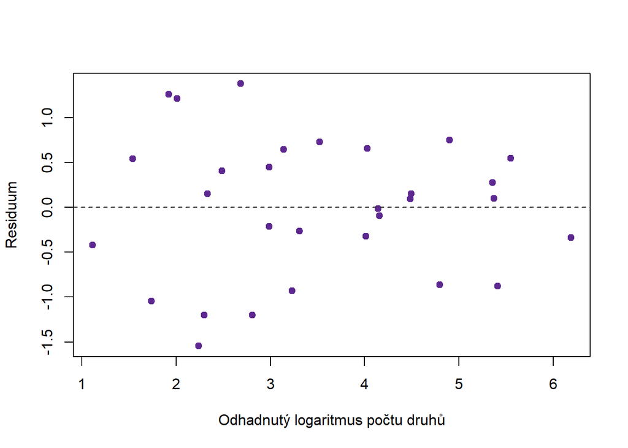

Residua mocninného vztahu podle odhadnutého logaritmu počtu druhů.

```r
# Residua podle odhadnutých hodnot
plot(
  x = fitted(object = mod_c_mocninny),
  y = residuals(object = mod_c_mocninny),
  pch = 19,
  col = "#5D2890",
  xlab = "Odhadnutý logaritmus počtu druhů",
  ylab = "Residuum"
)

abline(
  h = 0,
  col = "#2E2E2E",
  lty = 2
)
```

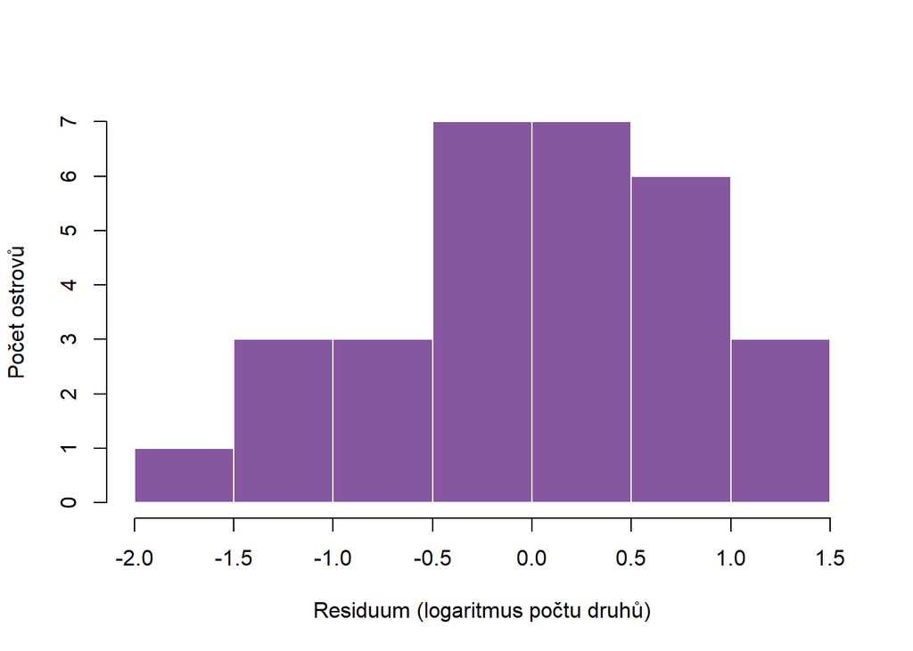

Histogram residuí mocninného vztahu.

```r
# Histogram residuí mocninného vztahu
hist(
  x = residuals(object = mod_c_mocninny),
  breaks = 10,
  col = "#86579E",
  border = "white",
  main = "",
  xlab = "Residuum (logaritmus počtu druhů)",
  ylab = "Počet ostrovů"
)
```

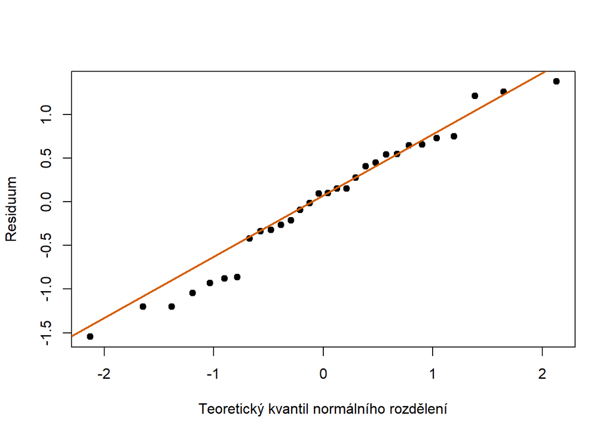

Q–Q graf residuí mocninného vztahu.

```r
# Q–Q graf residuí
qqnorm(
  y = residuals(object = mod_c_mocninny),
  pch = 19,
  main = "",
  xlab = "Teoretický kvantil normálního rozdělení",
  ylab = "Residuum"
)

qqline(
  y = residuals(object = mod_c_mocninny),
  col = "#D55E00",
  lwd = 2
)
```

```r
# Doplňující test normality residuí
shapiro.test(x = residuals(object = mod_c_mocninny))
```

```
    Shapiro-Wilk normality test

data:  residuals(object = mod_c_mocninny)
W = 0.97193, p-value = 0.5932
```

```r
# Největší vliv jednoho ostrova
max(cooks.distance(model = mod_c_mocninny))
```

```
[1] 0.1401268
```

**QuestionZůstal v residuích nějaký vzor?**

Porovnejte oba grafy s grafy residuí přímky. Vidíte ještě vějířJev, kdy rozptyl residuí není konstantní podél hodnot prediktoru - typicky se rozptýlení residuí zvětšuje s rostoucí odhadnutou hodnotou., oblouk nebo dlouhý chvost?

Residua tvoří přibližně stejně široký pás kolem nuly, Q–Q grafGraf, který porovnává seřazené hodnoty (typicky residua) s kvantily očekávanými u zvoleného rozdělení, nejčastěji normálního. je blízko přímky a Shapiro–Wilkův test odchylku neprokázal (p = 0.59). Žádný ostrov už model neovládá: největší Cookova vzdálenostMíra vlivu jednoho pozorování na model: vyjadřuje, jak moc by se změnily odhadnuté hodnoty, kdybychom toto pozorování vynechali. je 0.14, oproti 113.3 u přímky. Protože máme jen 30 ostrovů, čteme velkou p-hodnotuPravděpodobnost, že bychom při platnosti nulové hypotézy pozorovali data alespoň tak extrémní jako naše skutečná data. opatrně; přesvědčivé je hlavně to, že všechny tři kontroly ukazují stejným směrem.

Zmizel i vějíř, ve kterém se residua přímky směrem doprava rozšiřovala. Logaritmus převádí stejné *relativní* rozptýlení (například o několik desítek procent nahoru i dolů) na přibližně stejné absolutní rozptýlení na logaritmické škáleŠkála, na níž stejné vzdálenosti odpovídají stejným násobkům (např. 1, 10, 100); hodí se pro hodnoty rozprostřené přes několik řádů a pro násobné vztahy.. V lekci o porovnání více skupin jsme u rozdílné variability ve skupinách upozornili, že diagnostický graf nemá být automatickým příkazem k transformaciMatematická operace použitá na hodnoty proměnné (např. logaritmus); mění tvar rozdělení i to, jaký vztah model popisuje, například násobný místo součtového.. Zde transformaci nepoužíváme kvůli grafu, ale proto, že biologie předpovídá násobné změny; vyrovnaná residua jsou toho důsledkem.

# 7 Interpretace po transformaci

## 7.1 Kolikrát víc druhů má dvakrát větší ostrov?

Mocninný vztah dává odpověď na hlavní otázku. Odpověď se skrývá v jeho koeficientech.

```r
# Koeficienty a jejich 95% intervaly spolehlivosti
coef(object = mod_c_mocninny)
```

```
    (Intercept) log(plocha_km2)
      2.9037031       0.3885968
```

```r
confint(
  object = mod_c_mocninny,
  level = 0.95
)
```

```
                    2.5 %    97.5 %
(Intercept)     2.5819216 3.2254846
log(plocha_km2) 0.3033903 0.4738033
```

Model říká:

$$\text{logaritmus počtu druhů} =
\text{intercept} + \text{sklon} \times \text{logaritmus plochy}.$$

SklonParametr lineárního modelu udávající, o kolik se v průměru liší odezva dvou pozorování, jejichž prediktor se liší o jednu jednotku (při stejných hodnotách ostatních prediktorů). 0.389 neudává počet druhů na km². Na logaritmických osáchŠkála, na níž stejné vzdálenosti odpovídají stejným násobkům (např. 1, 10, 100); hodí se pro hodnoty rozprostřené přes několik řádů a pro násobné vztahy. znamená, že **když se logaritmus plochy zvětší o jednotku, logaritmus počtu druhů se zvětší o 0.389**. To je pro biologa málo názorné. Přeložíme to proto zpět do násobků. Zdvojnásobení plochy zvětší logaritmus plochy o $\ln(2)$, a tedy logaritmus počtu druhů o sklon × $\ln(2)$. Funkce `exp()`, opak logaritmu, převede tento přírůstek zpět na násobek: $\exp(0.389 \times 0.693) = \exp(0.269) = 1.31$. Stejné číslo dostaneme jednodušeji jako $2^{0.389}$. Slovy:

$$\text{násobek počtu druhů} =
\text{násobek plochy}^{\,\text{sklon}}.$$

Pro dvojnásobnou plochu:

$$\begin{align}
\text{násobek počtu druhů}
&= 2^{\,0.389} \\
&= 1.31.
\end{align}$$

**Ostrov s dvojnásobnou plochou má podle modelu typicky asi 1.31krát více druhů**, tedy zhruba o 31 % více, nikoli dvakrát více. 95% interval spolehlivostiRozsah hodnot vypočtený z dat postupem, který při opakovaných výběrech pokryje skutečnou hodnotu parametru ve zvoleném podílu případů (typicky 95 %). sklonu (0.30 až 0.47) odpovídá násobku 1.23 až 1.39.

Obecně mocninný vztah zapisujeme:

$$S = c \cdot A^{b}
\qquad\Longleftrightarrow\qquad
\ln(S) = \ln(c) + b \cdot \ln(A).$$

Symbol $S$ je typický počet druhů, $A$ plocha ostrova, $b$ **exponent** (sklon na logaritmických osách) a $c$ počet druhů očekávaný na ostrově o ploše 1 km² (jeho logaritmus je interceptParametr modelu: odhadnutá hodnota odezvy, když jsou všechny numerické prediktory rovny nule a kategoriální prediktory jsou v referenční skupině; geometricky jde o úsek na ose y.). Při vynásobení plochy číslem $k$ se počet druhů vynásobí číslem $k^b$. V ekologické literatuře se tento exponent obvykle značí $z$ (nezaměňovat se z-skóreHodnota převedená na počet směrodatných odchylek od průměru: z = (x − průměr) / SD; mění polohu a měřítko, ne tvar rozdělení.); pro souostroví se jeho odhady nejčastěji pohybují zhruba mezi 0,2 a 0,4 (Rosenzweig 1995, *Species Diversity in Space and Time*, Cambridge University Press).

**QuestionDesetkrát větší ostrov**

Spočítejte z exponentu, kolikrát více druhů má podle modelu typicky ostrov s desetinásobnou plochou. Porovnejte výsledek se svým odhadem ze začátku lekce.

**DůležitéŘešení**

$10^{\,0.389} = 2.45$. Desetkrát větší ostrov má typicky asi 2.45krát více druhů.

```r
# Typické počty druhů pro vybrané plochy ostrovů
data_nove_plochy <-
  data.frame(plocha_km2 = c(1, 10, 100, 1000))

# Model popisuje logaritmus; exp() jej převede zpět na počet druhů
exp(
  x = predict(
    object = mod_c_mocninny,
    newdata = data_nove_plochy
  )
)
```

```
        1         2         3         4
 18.24157  44.63330 109.20835 267.20995
```

**UpozorněníZpětný převod dává typickou, ne průměrnou hodnotu**

Model C odhaduje průměrSoučet hodnot vydělený jejich počtem; nejběžnější míra polohy (střední hodnoty). *logaritmu* počtu druhů. Po převodu funkcí `exp()` proto nedostaneme průměrný počet druhů, ale hodnotu blízkou mediánuHodnota rozdělující seřazená data na dvě stejně početné poloviny; 50% kvantil (prostřední kvartil).: typický ostrov dané plochy, kterého polovina ostrovů přesahuje a polovina nedosahuje. U pravostranně šikmých dat je průměr vyšší než tato typická hodnota. Číslo, které vznikne zpětným převodem průměru logaritmů, se nazývá **geometrický průměrn-tá odmocnina součinu n kladných hodnot; odpovídá zpětně transformovanému průměru logaritmů a hodí se pro násobné, pravostranně šikmé veličiny.**. U počtu druhů na Galapágách je geometrický průměr 33.4, medián 42 a aritmetický průměr 85.2. V první lekci jsme pro šikmá data doporučili medián; u dat, která jsou po logaritmování přibližně souměrná (log-normální), leží geometrický průměr blízko mediánu a přirozeně vzniká na logaritmické škále.

## 7.2 Jak číst koeficient, když logaritmujeme jen jednu stranu?

Mocninný vztah logaritmuje obě strany. Při logaritmování jen jedné strany se mění i význam koeficientu. Ukážeme to na kandidátechJeden z malé sady modelů, které před analýzou formulujeme podle biologických hypotéz a pak porovnáme na stejných datech. B, E a D, i když nevyšli jako nejlepší.

**QuestionStejný přírůstek, nebo stejný násobek?**

Model B tvrdí, že každé zdvojnásobení plochy přidá stejný počet druhů. Je takový přírůstek stejně velká změna pro ostrov s několika druhy a pro ostrov se stovkami druhů?

**Logaritmus jen prediktoruProměnná, pomocí níž vysvětlujeme variabilitu odezvy; v notaci y ~ x je prediktor x. (B: `pocet_druhu ~ log(plocha_km2)`).** SklonParametr lineárního modelu udávající, o kolik se v průměru liší odezva dvou pozorování, jejichž prediktor se liší o jednu jednotku (při stejných hodnotách ostatních prediktorů). 25.70 udává počet druhů přidaný při zvětšení logaritmu plochy o 1. Názornější je přepočet na zdvojnásobení plochy:

$$\text{přírůstek druhů na zdvojnásobení plochy} = \text{sklon} \times \ln(2).$$

$$25.70 \times 0.693 = 17.8.$$

Podle modelu B přidá každé zdvojnásobení plochy asi 17.8 druhu, ať jde o ostrov malý nebo velký. Pro ostrov s několika druhy je to velká relativní změna, pro ostrov se stovkami druhů malá. Mocninný vztah C naopak predikuje při každém zdvojnásobení stejnou *relativní* změnu. Obecně: přírůstek odezvyProměnná, jejíž variabilitu se snažíme vysvětlit nebo předpovědět; v notaci modelu y ~ x je odezva y. na $k$-násobek prediktoru je $b \cdot \ln(k)$, kde $b$ je sklon.

**Logaritmus jen odezvy (E: `log(pocet_druhu) ~ plocha_km2`).** Sklon 0.00078 udává změnu logaritmu počtu druhů na 1 km². Po zpětném převodu se z něj stává násobek:

$$\text{násobek počtu druhů na 100 km²} = \exp(100 \times \text{sklon}).$$

$$\exp(100 \times 0.00078) = 1.081.$$

Podle modelu E zvýší každých 100 km² počet druhů asi o 8.1 %. Obecně: při změně prediktoru o $\Delta x$ se odezva vynásobí číslem $\exp(b \cdot \Delta x)$. Pro malé sklony je $100 \cdot b$ přibližně procentní změna na jednotku prediktoru, protože pro malá $b$ platí $\exp(b) \approx 1 + b$.

**Kvadratický členDruhá mocnina prediktoru přidaná do lineárního modelu (např. y ~ x + I(x^2)); umožní popsat oblouk, a model přitom zůstane lineární v koeficientech. (D).** Model D nemá jeden sklon. Jak rychle počet druhů s plochou roste, se mění podél křivky: u malých ploch rychle, pak stále pomaleji, až kolem 2 766 km² přestane růst a začne klesat. Koeficienty kvadratického modelu proto nečteme jednotlivě. Čteme predikceHodnota odezvy, kterou model odhaduje pro nové pozorování nebo pro zvolenou kombinaci prediktorů, která nebyla mezi daty použitými k odhadu modelu. pro konkrétní plochy a místo vrcholu z grafu. Predikce mimo rozsah pozorovaných ploch jsou u paraboly obzvlášť riskantní, protože křivka pokračuje dolů, i když k tomu data nedávají žádný důvod.

**PoznámkaJak číst koeficienty po transformaci**

| Model | Co znamená sklon |
| --- | --- |
| `y ~ x` | změna `y` o sklon na jednotku `x` |
| `y ~ log(x)` | změna `y` o sklon × ln(2) na každé zdvojnásobení `x` |
| `log(y) ~ x` | vynásobení `y` číslem exp(sklon) na jednotku `x`; přibližně 100 × sklon % pro malé sklony |
| `log(y) ~ log(x)` | vynásobení `y` číslem 2^sklon na každé zdvojnásobení `x` |
| `y ~ x + I(x^2)` | sklon se mění podél křivky; čteme predikce, ne jednotlivé koeficienty |

## 7.3 Jak rychle roste počet druhů s plochou ostrova?

**DůležitéOdpověď na hlavní otázku**

Počet druhů rostlin na Galapágách roste s plochou ostrova podle mocninného vztahu s exponentem asi 0.39 (95% interval spolehlivostiRozsah hodnot vypočtený z dat postupem, který při opakovaných výběrech pokryje skutečnou hodnotu parametru ve zvoleném podílu případů (typicky 95 %). 0.30 až 0.47). Dvojnásobná plocha znamená typicky asi 1.31krát více druhů a desetinásobná plocha asi 2.45krát více. **Počet druhů tedy roste s plochou, ale mnohem pomaleji než plocha samotná.**

Tento závěr podporují tři argumenty, které ale vycházejí ze stejných ostrovů: biologicky zdůvodněný tvar vztahu, residuaRozdíl mezi pozorovanou hodnotou odezvy a hodnotou odhadnutou modelem: eᵢ = yᵢ − ŷᵢ. bez systematického vzoru a nejnižší AICMíra kvality modelu, která penalizuje složitost - čím nižší AIC, tím lepší poměr mezi přesností modelu a počtem jeho parametrů. mezi modely pro logaritmus počtu druhů. S modely pro samotný počet druhů (A, B, D) model C pomocí AIC porovnat nelze; od nich jej odlišují biologický smysl a residua. Závěr má také jasná omezení:

- Máme jen 30 ostrovů, takže diagnostické grafy i test normality mají omezenou citlivost.
- OdezvouProměnná, jejíž variabilitu se snažíme vysvětlit nebo předpovědět; v notaci modelu y ~ x je odezva y. je počet. Model, který s počty pracuje přímo, by mohl lépe popsat malé ostrovy s několika druhy.
- Ostrovy jednoho souostroví nejsou úplně nezávislé: sdílejí dodavatelské ostrovy, klima i historii osídlení.
- Plocha souvisí s dalšími vlastnostmi ostrova, například s nadmořskou výškou a rozmanitostí prostředí. Mocninný vztah popisuje souvislost, nikoli to, že plocha sama o sobě druhy „vytváří“.

**QuestionNapište vlastní závěr**

Shrňte ve dvou větách, co jste se o vztahu plochy a počtu druhů dozvěděli. Uveďte jedno číslo s interpretací a jedno omezení.

**DůležitéPříklad odpovědi**

Na Galapágách má ostrov s dvojnásobnou plochou typicky asi o 31 % více druhů rostlin, jak ukazuje mocninný vztah s exponentem 0.39. Závěr vychází z pouhých 30 ostrovů jednoho souostroví, takže jeho přenos na jiná souostroví je nejistý.

Úvodní otázku o stromech z předchozí lekce zbývá uzavřít. Stejný postup můžeme vyzkoušet i na ní.

**TipNávrat ke stromům: zmizí oblouk v residuích?**

Na začátku lekce jsme si připomněli oblouk v residuích modelu Posun mezi druhy (aditivní modelModel s více prediktory bez interakce: příspěvky prediktorů se sčítají, takže vztah odezvy k jednomu prediktoru je stejný při všech hodnotách ostatních.) pro výšku jehličnanů. Stejně jako u ostrovů zvažme biologicky věrohodný tvar: výška stromu roste s průměrem kmene stále pomaleji, protože strom nemůže růst do výšky donekonečna. Takové zpomalení vyjadřuje logaritmus průměru kmene.

```r
# Načteme stromy z předchozí lekce
data_stromy_l <-
  read.csv(
    file = here::here("data", "allometrie_stromu.csv"),
    stringsAsFactors = TRUE
  )

# Aditivní model z předchozí lekce
mod_stromy_primka <-
  lm(
    formula = vyska_stromu_m ~ prumer_kmene_cm + druh_stromu,
    data = data_stromy_l
  )

# Stejný model s logaritmem průměru kmene
mod_stromy_log_prumer <-
  lm(
    formula = vyska_stromu_m ~ log(prumer_kmene_cm) + druh_stromu,
    data = data_stromy_l
  )

# Oba modely mají stejnou odezvu, takže AIC můžeme porovnat
AIC(object = mod_stromy_primka)
```

```
[1] 395.4366
```

```r
AIC(object = mod_stromy_log_prumer)
```

```
[1] 350.6625
```

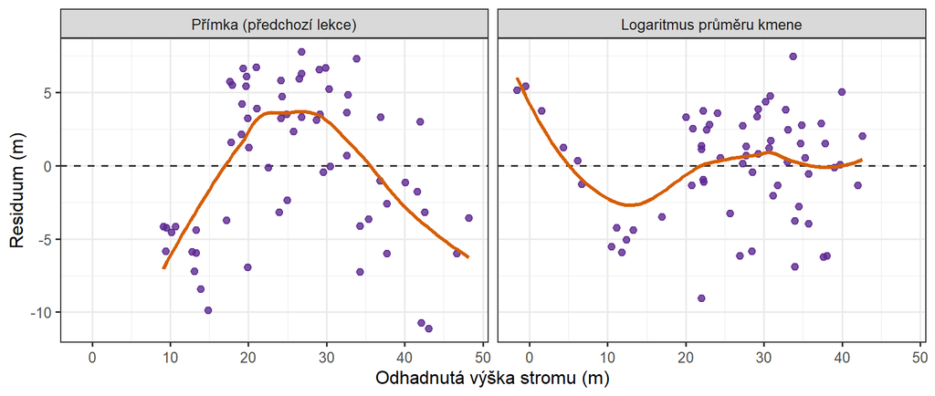

Residua dvou modelů výšky stromů podle odhadnuté výšky. Oranžová křivka pouze vyhlazuje průběh bodů.

Oblouk se zploštil, ale nezmizel úplně: stromy s odhadnutou výškou zhruba 10–20 m model stále systematicky přeceňuje (jejich residua leží převážně pod nulou), zatímco u vyšších stromů leží residua kolem nuly. AIC kleslo z 395.4 na 350.7. Odpověď na otázku z předchozí lekce tedy zní: **tvar vztahu byl hlavní, i když ne jediný problém.** Nižší stromy by si zasloužily další pozornost, například jiný tvar vztahu nebo kontrolu jejich měření. Podle nového modelu přidá každé zdvojnásobení průměru kmene stromu asi 10.3 m výšky.

Kvadratický model by měl AIC ještě o něco nižší (341.3). Jeho parabola má ale vrchol u průměru kmene asi 61 cm a pro 6 nejširších stromů predikuje, že jsou *nižší* než užší stromy. Je to stejná lekce jako u ostrovů: nejnižší AIC nenahradí biologickou úvahu o tvaru vztahu.

## 7.4 Kdy transformaci použít a kdy ne?

Postup z této lekce lze použít i na jiná data:

1. Položte biologickou otázku a prohlédněte data, včetně tvaru rozděleníPopis toho, jaké hodnoty proměnná nabývá a jak často se vyskytují; může jít o pozorované rozdělení dat nebo o teoretické pravděpodobnostní rozdělení. hlavních proměnných.
2. Odhadněte nejjednodušší rozumný model a zkontrolujte jeho residuaRozdíl mezi pozorovanou hodnotou odezvy a hodnotou odhadnutou modelem: eᵢ = yᵢ − ŷᵢ.: graf podle odhadnutých hodnotHodnota odezvy, kterou fitovaný model přiřadí pozorování na základě jeho hodnot prediktorů; značí se často ŷ., Q–Q grafGraf, který porovnává seřazené hodnoty (typicky residua) s kvantily očekávanými u zvoleného rozdělení, nejčastěji normálního. a vliv jednotlivých pozorováníJeden zaznamenaný případ v datech, který obsahuje hodnoty jedné nebo více proměnných.. Test normality čtěte až po grafech a s ohledem na počet pozorování.
3. Pokud residua ukazují systematický vzor, zeptejte se, jaký tvar vztahu předpovídá biologie: stejný přírůstek, stejný násobek, zpomalující růst, nebo optimum?
4. Převeďte biologická tvrzení na malou sadu kandidátních formulí s `log()` nebo `I(x^2)`.
5. Porovnejte kandidáty na původní škále v grafu, pomocí residuí a pomocí AICMíra kvality modelu, která penalizuje složitost - čím nižší AIC, tím lepší poměr mezi přesností modelu a počtem jeho parametrů., ale AIC jen mezi modely se stejnou odezvouProměnná, jejíž variabilitu se snažíme vysvětlit nebo předpovědět; v notaci modelu y ~ x je odezva y..
6. Výsledek interpretujte v původních jednotkách: násobky, přírůstky na zdvojnásobení, procenta.

**UpozorněníTransformace není rituál**

TransformaciMatematická operace použitá na hodnoty proměnné (např. logaritmus); mění tvar rozdělení i to, jaký vztah model popisuje, například násobný místo součtového. volíme proto, že vyjadřuje biologické tvrzení o vztahu, nikoli proto, aby test normality vrátil velkou p-hodnotuPravděpodobnost, že bychom při platnosti nulové hypotézy pozorovali data alespoň tak extrémní jako naše skutečná data.. Lineární transformace (z-skóreHodnota převedená na počet směrodatných odchylek od průměru: z = (x − průměr) / SD; mění polohu a měřítko, ne tvar rozdělení., centrováníOdečtení průměru (nebo jiné zvolené hodnoty) od všech hodnot proměnné; posune polohu, ale nezmění tvar rozdělení ani rozptyl.) tvar rozdělení neopraví nikdy. A pokud šikmá je jen odezva nebo prediktorProměnná, pomocí níž vysvětlujeme variabilitu odezvy; v notaci y ~ x je prediktor x., ale residua jsou v pořádku, není co opravovat kvůli normalitě. Vlivná pozorováníPozorování, jehož vynechání by výrazně změnilo odhadnutý model; vlivná bývají hlavně pozorování s velkým pákovým efektem i velkým residuem., jako byla Isabela u přímky, ale sledujeme vždy.

**TipJsou ostrovy jednoho souostroví nezávislá pozorování?**

Všech 30 ostrovů leží v jednom souostroví. Sousední ostrovy si vyměňují semena, sdílejí podnebí a mají společnou historii. Jsou to opravdu 30 nezávislých kousků informace? Co když data obsahují měření ze stejných lokalit, bloků nebo jedinců? Těmito otázkami se budeme zabývat v následující lekci. Později se také vrátíme k počtům druhů a ukážeme modely, které s počty a podíly pracují přímo, bez transformace.

# Shrnutí

- Tvar rozděleníPopis toho, jaké hodnoty proměnná nabývá a jak často se vyskytují; může jít o pozorované rozdělení dat nebo o teoretické pravděpodobnostní rozdělení. popisujeme slovy (souměrné, pravostranně a levostranně šikmé, těžké chvosty, dva vrcholy, omezené hodnoty), histogramemGraf zobrazující rozdělení hodnot numerické proměnné: hodnoty jsou rozděleny do sousedních intervalů (košů), výška sloupce udává četnost v daném koši. a Q–Q grafemGraf, který porovnává seřazené hodnoty (typicky residua) s kvantily očekávanými u zvoleného rozdělení, nejčastěji normálního..
- Mnoho biologických veličin je pravostranně šikmých, protože jsou zdola omezené nulou nebo vznikají násobením.
- Lineární modelStatistický model, v němž je průměrná odezva součtem interceptu a prediktorů násobených koeficienty; lineární je v koeficientech, takže nemusí jít jen o přímku. předpokládá přibližně normální rozděleníSouměrné zvonovité pravděpodobnostní rozdělení určené průměrem a směrodatnou odchylkou; lineární model předpokládá přibližně normální rozdělení residuí. **residuíRozdíl mezi pozorovanou hodnotou odezvy a hodnotou odhadnutou modelem: eᵢ = yᵢ − ŷᵢ.**, nikoli odezvyProměnná, jejíž variabilitu se snažíme vysvětlit nebo předpovědět; v notaci modelu y ~ x je odezva y. nebo prediktorůProměnná, pomocí níž vysvětlujeme variabilitu odezvy; v notaci y ~ x je prediktor x.. Test normality residuí doplňuje Q–Q graf a jeho výsledek závisí na počtu pozorováníJeden zaznamenaný případ v datech, který obsahuje hodnoty jedné nebo více proměnných..
- Změna jednotek, centrováníOdečtení průměru (nebo jiné zvolené hodnoty) od všech hodnot proměnné; posune polohu, ale nezmění tvar rozdělení ani rozptyl. a z-skóreHodnota převedená na počet směrodatných odchylek od průměru: z = (x − průměr) / SD; mění polohu a měřítko, ne tvar rozdělení. mění jen polohu a měřítko; tvar rozdělení zachovají. Logaritmus a odmocnina mění tvar.
- Logaritmus převádí stejné násobky na stejné kroky, a proto umí z mocninného vztahu udělat přímku.
- Kandidátní tvary vztahu odvozujeme z biologie a porovnáváme grafem, residui a AICMíra kvality modelu, která penalizuje složitost - čím nižší AIC, tím lepší poměr mezi přesností modelu a počtem jeho parametrů., ale AIC jen mezi modely se stejnou odezvou.
- Po transformaciMatematická operace použitá na hodnoty proměnné (např. logaritmus); mění tvar rozdělení i to, jaký vztah model popisuje, například násobný místo součtového. se mění význam koeficientů: sklonParametr lineárního modelu udávající, o kolik se v průměru liší odezva dvou pozorování, jejichž prediktor se liší o jednu jednotku (při stejných hodnotách ostatních prediktorů). mocninného vztahu udává, kolikrát se změní odezva při zdvojnásobení prediktoru.

# Slovníček pojmů

Pojmy použité v těchto materiálech a jejich definice:

| term | definition |
| --- | --- |
| aditivni-model | Model s více prediktory bez interakce: příspěvky prediktorů se sčítají, takže vztah odezvy k jednomu prediktoru je stejný při všech hodnotách ostatních. |
| aic | Míra kvality modelu, která penalizuje složitost - čím nižší AIC, tím lepší poměr mezi přesností modelu a počtem jeho parametrů. |
| bodovy-graf | Graf vztahu dvou numerických proměnných, v němž každý bod představuje jedno pozorování a jeho dvě hodnoty určují polohu na osách. |
| centrovani | Odečtení průměru (nebo jiné zvolené hodnoty) od všech hodnot proměnné; posune polohu, ale nezmění tvar rozdělení ani rozptyl. |
| cetnost | Počet výskytů určité hodnoty nebo kategorie v datové sadě; pro kategoriální proměnné je četnost základní deskriptivní statistikou. |
| cookova-vzdalenost | Míra vlivu jednoho pozorování na model: vyjadřuje, jak moc by se změnily odhadnuté hodnoty, kdybychom toto pozorování vynechali. |
| geometricky-prumer | n-tá odmocnina součinu n kladných hodnot; odpovídá zpětně transformovanému průměru logaritmů a hodí se pro násobné, pravostranně šikmé veličiny. |
| heteroskedasticita | Jev, kdy rozptyl residuí není konstantní podél hodnot prediktoru - typicky se rozptýlení residuí zvětšuje s rostoucí odhadnutou hodnotou. |
| histogram | Graf zobrazující rozdělení hodnot numerické proměnné: hodnoty jsou rozděleny do sousedních intervalů (košů), výška sloupce udává četnost v daném koši. |
| interakce-predikatoru | Situace, kdy efekt jednoho prediktoru na odezvu závisí na hodnotě jiného prediktoru. |
| intercept | Parametr modelu: odhadnutá hodnota odezvy, když jsou všechny numerické prediktory rovny nule a kategoriální prediktory jsou v referenční skupině; geometricky jde o úsek na ose y. |
| interval-spolehlivosti | Rozsah hodnot vypočtený z dat postupem, který při opakovaných výběrech pokryje skutečnou hodnotu parametru ve zvoleném podílu případů (typicky 95 %). |
| iqr | Rozdíl mezi 3. kvartilem (Q3) a 1. kvartilem (Q1); pokrývá prostředních 50 % dat a je robustní vůči odlehlým pozorováním. |
| kandidatni-model | Jeden z malé sady modelů, které před analýzou formulujeme podle biologických hypotéz a pak porovnáme na stejných datech. |
| korelace | Bezrozměrné číslo popisující směr a těsnost vztahu dvou proměnných; Pearsonova korelace shrnuje lineární vztah a Spearmanova monotónní vztah podle pořadí. |
| kriticka-hodnota | Násobitel standardní chyby použitý při konstrukci intervalu, nebo hranice testové statistiky v testu; závisí na hladině, stupních volnosti a zvoleném rozdělení. |
| kvadraticky-clen | Druhá mocnina prediktoru přidaná do lineárního modelu (např. y ~ x + I(x^2)); umožní popsat oblouk, a model přitom zůstane lineární v koeficientech. |
| kvantil | Hodnota, pod níž leží určený podíl seřazených dat; medián je 50% kvantil. |
| linearni-model | Statistický model, v němž je průměrná odezva součtem interceptu a prediktorů násobených koeficienty; lineární je v koeficientech, takže nemusí jít jen o přímku. |
| logaritmicka-skala | Škála, na níž stejné vzdálenosti odpovídají stejným násobkům (např. 1, 10, 100); hodí se pro hodnoty rozprostřené přes několik řádů a pro násobné vztahy. |
| median | Hodnota rozdělující seřazená data na dvě stejně početné poloviny; 50% kvantil (prostřední kvartil). |
| metoda-nejmensich-ctvercu | Postup, který volí koeficienty modelu tak, aby byl součet čtverců residuí (RSS) co nejmenší; takto odhaduje koeficienty funkce lm(). |
| nelinearita | Situace, kdy vztah mezi prediktorem a odezvou není dobře popsatelný přímkou - má zakřivení nebo jinou nelineární formu. |
| normalni-rozdeleni | Souměrné zvonovité pravděpodobnostní rozdělení určené průměrem a směrodatnou odchylkou; lineární model předpokládá přibližně normální rozdělení residuí. |
| nulova-hypoteza | Výchozí předpoklad, který testujeme - typicky 'efekt je nulový' nebo 'skupiny se neliší'; p-hodnota udává pravděpodobnost dat alespoň tak extrémních jako naše za předpokladu platnosti H₀. |
| numericka-promenna | Proměnná, jejíž hodnoty jsou čísla se smysluplnou velikostí nebo rozdílem; může být diskrétní, například počet, nebo spojitá, například délka. |
| odezva | Proměnná, jejíž variabilitu se snažíme vysvětlit nebo předpovědět; v notaci modelu `y ~ x` je odezva `y`. |
| odhadnuta-hodnota | Hodnota odezvy, kterou fitovaný model přiřadí pozorování na základě jeho hodnot prediktorů; značí se často ŷ. |
| odlehla-pozorovani | Pozorování, které se výrazně odlišuje od ostatních - v hodnotě jedné proměnné, nebo v modelu velkým residuem; může jít o chybu měření i o skutečně neobvyklý případ. |
| p-hodnota | Pravděpodobnost, že bychom při platnosti nulové hypotézy pozorovali data alespoň tak extrémní jako naše skutečná data. |
| pakovy-efekt | Míra toho, jak neobvyklé hodnoty prediktorů má jedno pozorování ve srovnání s ostatními; nezávisí na naměřené odezvě. |
| pozorovani | Jeden zaznamenaný případ v datech, který obsahuje hodnoty jedné nebo více proměnných. |
| predikce | Hodnota odezvy, kterou model odhaduje pro nové pozorování nebo pro zvolenou kombinaci prediktorů, která nebyla mezi daty použitými k odhadu modelu. |
| prediktor | Proměnná, pomocí níž vysvětlujeme variabilitu odezvy; v notaci `y ~ x` je prediktor `x`. |
| promenna | Vlastnost zaznamenaná u pozorování, která může mezi pozorováními nabývat různých hodnot, například druh, délka nebo počet. |
| prumer | Součet hodnot vydělený jejich počtem; nejběžnější míra polohy (střední hodnoty). |
| qq-graf | Graf, který porovnává seřazené hodnoty (typicky residua) s kvantily očekávanými u zvoleného rozdělení, nejčastěji normálního. |
| r2 | Podíl variability odezvy zachycený modelem: R² = 1 − RSS / celkový součet čtverců (0 = model nezachytí nic navíc oproti průměru, 1 = zachytí vše). |
| residuum | Rozdíl mezi pozorovanou hodnotou odezvy a hodnotou odhadnutou modelem: eᵢ = yᵢ − ŷᵢ. |
| rozdeleni | Popis toho, jaké hodnoty proměnná nabývá a jak často se vyskytují; může jít o pozorované rozdělení dat nebo o teoretické pravděpodobnostní rozdělení. |
| rozptyl | Součet čtverců odchylek od průměru dělený n − 1; míra variability dat. Odmocnina rozptylu je směrodatná odchylka. |
| sikmost | Nesouměrnost rozdělení: u pravostranně šikmého rozdělení se hodnoty táhnou dlouhým chvostem vpravo k vysokým hodnotám a průměr bývá větší než medián. |
| sila-testu | Pravděpodobnost, že test zamítne nulovou hypotézu, když skutečný efekt dané velikosti existuje; je to 1 − β. |
| simulace | Opakované vytváření umělých dat podle známého modelu na počítači; ukazuje, jak se odhady, intervaly nebo testy chovají napříč mnoha výběry. |
| sklon | Parametr lineárního modelu udávající, o kolik se v průměru liší odezva dvou pozorování, jejichž prediktor se liší o jednu jednotku (při stejných hodnotách ostatních prediktorů). |
| smerodatna-odchylka | Odmocnina rozptylu; vyjadřuje typickou vzdálenost hodnot od průměru ve stejných jednotkách jako původní data. |
| standardni-chyba | Míra přesnosti odhadu parametru (průměru, sklonu…); odhaduje z jediného výběru, jak moc by se odhady typicky lišily mezi opakovanými výběry stejné velikosti. |
| stupne-volnosti | Počet nezávislých informací dostupných pro odhad parametru; počet pozorování minus počet odhadovaných parametrů. |
| t-rozdeleni | Souměrné rozdělení podobné normálnímu, ale s těžšími chvosty; jeho tvar určují stupně volnosti a používá se pro t-statistiku a intervaly spolehlivosti. |
| t-statistika | Testová statistika: rozdíl odhadu od hodnoty v nulové hypotéze (obvykle 0) vydělený standardní chybou; říká, o kolik standardních chyb je odhad od nuly. |
| transformace | Matematická operace použitá na hodnoty proměnné (např. logaritmus); mění tvar rozdělení i to, jaký vztah model popisuje, například násobný místo součtového. |
| vlivne-pozorovani | Pozorování, jehož vynechání by výrazně změnilo odhadnutý model; vlivná bývají hlavně pozorování s velkým pákovým efektem i velkým residuem. |
| vyber | Soubor pozorování, z něhož počítáme statistiky a pomocí něhož se snažíme popsat širší populaci nebo proces. |
| z-skore | Hodnota převedená na počet směrodatných odchylek od průměru: z = (x − průměr) / SD; mění polohu a měřítko, ne tvar rozdělení. |